# Module 2 Project - Clustering Algorithms

# Creating a t-SNE visualization

```python
#Extracting labels

target_labels = model.predict(df)

#Converting the labels to a series

target_labels = pd.Series(target_labels)

#Merging the labels to the dataset

df = pd.merge(df, pd.DataFrame(target_labels), left_index=True, right_index=True)

#Renaming the target

df['type'] = df[0]
df = df.drop([0], axis = 1)
```

```python
from sklearn.manifold import TSNE

#Creating the features

features = df.drop('type', axis = 1).values

target = df['type'].values

#Initialize a TSNE object

tsne_object = TSNE()

#Fit and transform the features using the TSNE object

transformed = tsne_object.fit_transform(features)
```

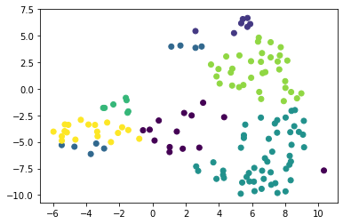

```python
#Creating a t-SNE visualization with 7 clusters

x_axis = transformed[:,0]
y_axis = transformed[:,1]
plt.scatter(x_axis, y_axis, c = target)
plt.savefig('9.png')
plt.show()
```

# Supervised Clustering

# 10. kNN Function

```python
# Create a function of predictKNN to predict the types of the neighborhood.
```

```python
def predictKNN(k,df,input):

    knn = KNeighborsClassifier(n_neighbors = 3, p = 2)   # p=2 for euclidean distance
    knn.fit(df[df.columns[:-1]], df.type)

    [population,educated,age,employer,gym,venue] = input
    classification = range(k-1)

    data_class = knn.predict(np.array(input).reshape(1, -1))[0]
    return(classification[data_class])
```

### Attention: the parameter of input in predictKNN function has the probility of not working because the order of clusters is not fixed. And the boundary of each cluster is not the same.

```python
# Predict the type of the neighborhoods through predictKNN function.
```

```python
predictKNN(7,df,[0.7,0.7,0.7,0.7,0.16,0.012])
```

```
1
```

```python
predictKNN(7,df,[0.2,0.2,0.1,0.2,0.8,0.06])
```

```
0
```

```python
predictKNN(7,df,[0.3,0.4,0.3,0.3,0.03,0.13])
```

```
5
```

```python
predictKNN(7,df,[0.14,0.12,0.12,0.07,0.17,0.12])
```

```
3
```

```python
predictKNN(7,df,[0.49,0.47,0.48,0.7,0.8,0.014])
```

```
5
```

# Findings

# 11. Project Report:

To assist the Canadian Government select the best location of a new gym, I use the Dendrogram, K-means and KNN algorithms to find the best neighborhoods.

I got 5 best neighborhoods based on the dendrogram:  
L'Amoreaux  
Malvern  
Rouge  
Willowdale East  
Woburn

I fit and transform the six features using the TSNE object and create a two-dimensional t-SNE visualization with 7 clusters.

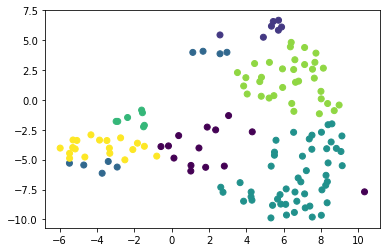

```python
x_axis = transformed[:,0]
y_axis = transformed[:,1]
plt.scatter(x_axis, y_axis, c = target)
plt.savefig('9.png')
plt.show()
```

# Summary

# Originality

The dataset I use comes from kaggle: https://www.kaggle.com/youssef19/toronto-neighborhoods-inforamtion No other similar published works for clustering analysis found with the same dataset.